# Topic Model Discrepencies

Alex White

March 18, 2016

```r
######## READ IN DATA #######

library(maptpx)
library(CountClust)

data=read.csv("../external_data/Himalayan_grid_matrix.csv",header=TRUE);

counts=as.matrix(data[,-1]);

rownames(counts)=data[,1];

new_data1 <- data.frame(read.csv('../external_data/MohanGrids.csv'));
new_data2 <- data.frame(read.csv('../external_data/MohanGrids2.csv'));

bird_species <- union(as.vector(colnames(counts)), union(as.vector(new_data1[,1]), as.vector(new_data2[,1])));

new_data <- matrix(0,dim(counts)[1]+3,length(bird_species));
new_data[1,match(new_data1[,1],bird_species)]=new_data1[,2];
new_data[2,match(new_data1[,1],bird_species)]=new_data1[,3];
new_data[3,match(new_data2[,1],bird_species)]=new_data2[,2];
new_data[4:(dim(counts)[1]+3),match(colnames(counts),bird_species)]=counts;

new_counts <- as.matrix(new_data);

rownames(new_counts) <- c(c("U1","U2","MA1"),rownames(counts));
colnames(new_counts) <- bird_species;
new_counts <- new_counts[-(1:3),];

metadata=read.csv("../external_data/Himalayan_grid_metadata.csv",header=TRUE,row.names = 1);
elevation_metadata=metadata$Elevation[match(rownames(new_counts),rownames(metadata))];
east_west_dir = metadata$WorE

cbbPalette <- c("#000000", "#E69F00", "#56B4E9", "#009E73", "#F0E442", "#0072B2", "#D55E00", "#CC79A7")

forest_patch_label <- rownames(metadata)
```

There will be TWO ways of procuding the data, they should have the same content, but they are producing two different omega matrices for K=4. I will show the discrepencies below. The first way to input the data is using the new_counts matrix from above. I will also show that these two different ways of inputting the data produce the SAME k=3 result, meaning there must be a problem with the model when K=4, and not some problem with plotting or somthing like that.

```r
#Check.BF <- topics(new_counts, K=c(2,3,4,5,6), tol=0.00001, kill=0)
K.3 <- topics(new_counts, K=3, tol=0.00001, kill=0)
```

```
##
## Estimating on a 35 document collection.
## Fitting the 3 topic model.
## log posterior increase: 411.26231, 18.75151, 2.86004, 4.65647, 8.98437, 14.96111, 10.85817, 23.89921, 0.34434, 2.05533, 1.27865, 0.02384, 0.00068, 5e-05, 1e-05, done.
```

```r
#K.3$omega
K.4 <- topics(new_counts, K=4, tol=0.00001, kill=0)
```

```
##
## Estimating on a 35 document collection.
## Fitting the 4 topic model.
## log posterior increase: 900.26044, 18.34211, 7.12073, 6.93121, 9.12483, 28.30257, 19.82937, 8.68628, 8.35785, 0.05252, 0.00156, 0.00022, 0.00018, 2e-04, 0.00019, 0.00016, 0.00011, 7e-05, 3e-05, 2e-05, 1e-05, done.
```

```r
#K.4$omega
```

The strucutre plots for K=3 and K=4 are shown below.

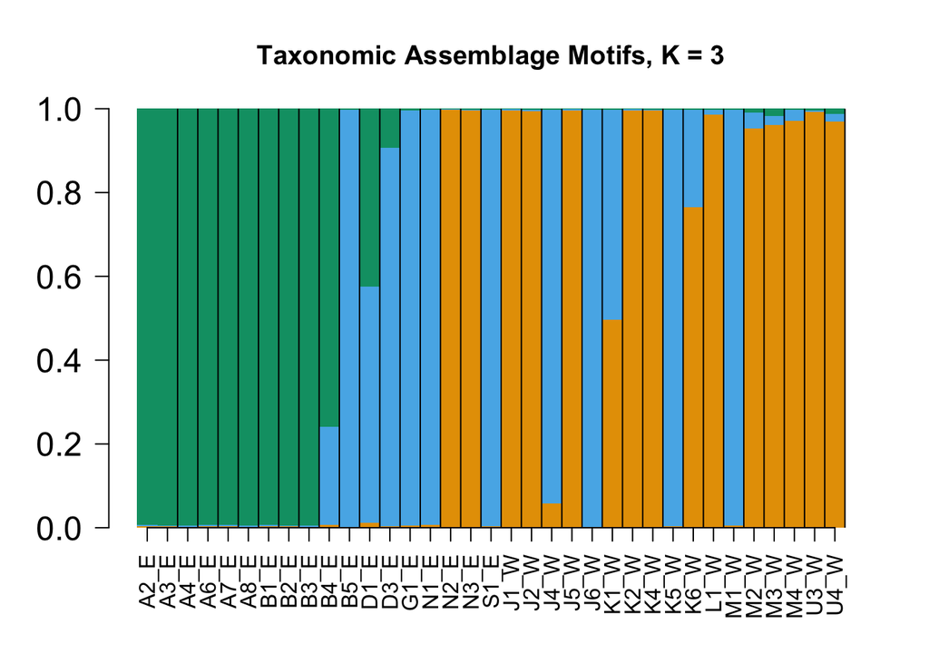

```r
K <- 3
barplot(t(K.3$omega[order(elevation_metadata),]),col=cbbPalette[2:(K+1)],axisnames=F,space=0,border=NA,
        main="",las=1,ylim=c(0,1),cex.axis=1.5,cex.main=1.4)
title(main=paste("Taxonomic Assemblage Motifs, K =",K))
combo_patch_dir = paste0(forest_patch_label,"_",east_west_dir);
combo_patch_dir_ordered = combo_patch_dir[order(east_west_dir)];
match_labs=match(unique(combo_patch_dir_ordered),combo_patch_dir_ordered);
match_labs_suffix=c(match_labs[2:length(unique(combo_patch_dir_ordered))],35);
match_labs_prefix=match_labs[1:(length(unique(combo_patch_dir_ordered)))];
labs=match_labs_prefix + 0.5*(match_labs_suffix - match_labs_prefix);
labs=c(0.5,1.5,2.5,3.5,4.5,5.5,6.5,7.5,8.5,9.5,10.5,11.5,12.5,13.5,14.5,15.5,16.5,17.5,18.5,19.5,20.5,21.5,22.5,23.5,24.5,25.5,26.5,27.5,28.5,29.5,30.5,31.5,32.5,33.5,34.5)
axis(1,at=labs,unique(combo_patch_dir_ordered),las=2);
abline(v=match_labs[2:length(match_labs)]);
```

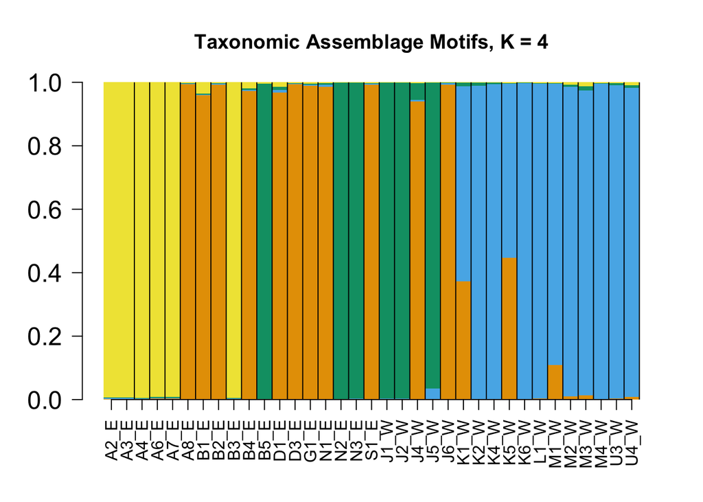

```r
K <- 4
barplot(t(K.4$omega[order(elevation_metadata),]),col=cbbPalette[2:(K+1)],axisnames=F,space=0,border=NA,
        main="",las=1,ylim=c(0,1),cex.axis=1.5,cex.main=1.4)
title(main=paste("Taxonomic Assemblage Motifs, K =",K))
combo_patch_dir = paste0(forest_patch_label,"_",east_west_dir);
combo_patch_dir_ordered = combo_patch_dir[order(east_west_dir)];
match_labs=match(unique(combo_patch_dir_ordered),combo_patch_dir_ordered);
match_labs_suffix=c(match_labs[2:length(unique(combo_patch_dir_ordered))],35);
match_labs_prefix=match_labs[1:(length(unique(combo_patch_dir_ordered)))];
labs=match_labs_prefix + 0.5*(match_labs_suffix - match_labs_prefix);
labs=c(0.5,1.5,2.5,3.5,4.5,5.5,6.5,7.5,8.5,9.5,10.5,11.5,12.5,13.5,14.5,15.5,16.5,17.5,18.5,19.5,20.5,21.5,22.5,23.5,24.5,25.5,26.5,27.5,28.5,29.5,30.5,31.5,32.5,33.5,34.5)
axis(1,at=labs,unique(combo_patch_dir_ordered),las=2);
abline(v=match_labs[2:length(match_labs)]);
```

```r
No_zero_counts <- new_counts[,colnames(new_counts[,which(colSums(new_counts) > 0)])]
```

```r
#Check.BF.second <- topics(No_zero_counts, K=c(2,3,4,5,6), tol=0.00001, kill=0)
new.K.3 <- topics(No_zero_counts, K=3, tol=0.00001, kill=0)
```

```
##
## Estimating on a 35 document collection.
## Fitting the 3 topic model.
## log posterior increase: 429.45145, 16.9343, 2.81987, 4.1218, 6.81546, 7.73199, 9.32044, 30.64923, 0.15564, 25.82976, 0.10741, 0.01105, 0.00039, 3e-05, done.
```

```r
#new.K.3$omega
new.K.4 <- topics(No_zero_counts, K=4, tol=0.00001, kill=0)
```

```
##
## Estimating on a 35 document collection.
## Fitting the 4 topic model.
## log posterior increase: 554.97916, 28.52246, 15.7077, 2.09371, 1.27678, 26.23123, 13.05286, 0.00557, 0.24253, 0.54347, 4.23854, 0.01039, 0.06822, 3e-04, 1e-04, 5e-05, 3e-05, 2e-05, 1e-05, done.
```

```r
#new.K.4$omega
```

The omega matrix for K=3 is similar to the original result above, but the K=4 result is clearly different. And now the structure plot for both Ks.

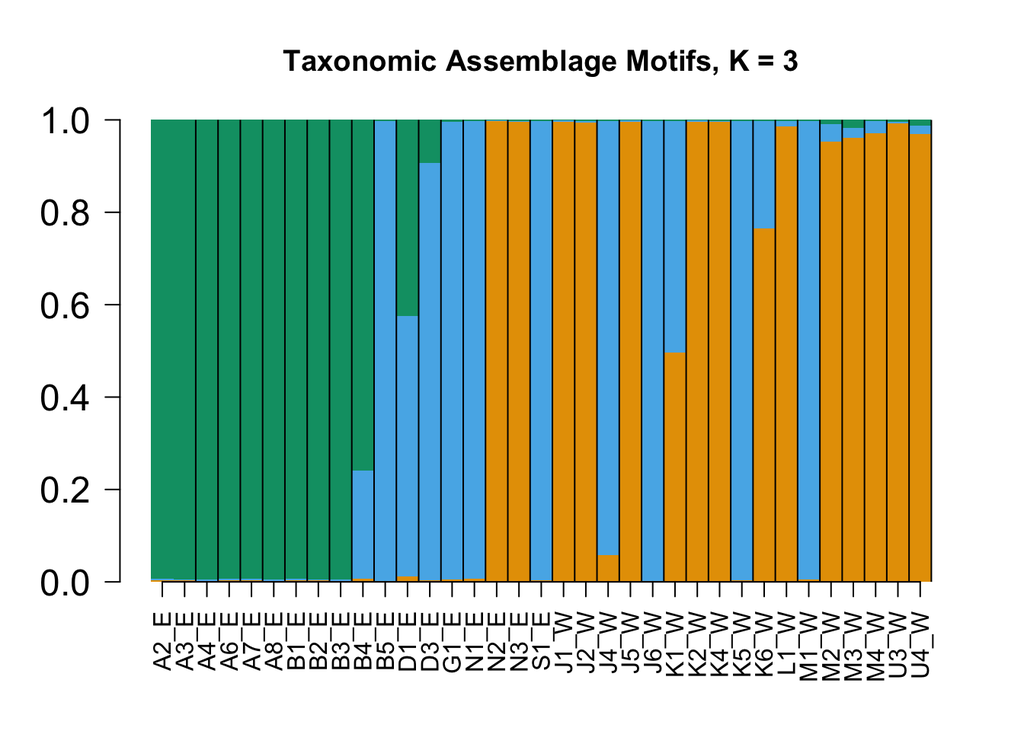

```r
K <- 3
barplot(t(new.K.3$omega[order(elevation_metadata),]),col=cbbPalette[2:(K+1)],axisnames=F,space=0,border=NA,
        main="",las=1,ylim=c(0,1),cex.axis=1.5,cex.main=1.4)
title(main=paste("Taxonomic Assemblage Motifs, K =",K))
combo_patch_dir = paste0(forest_patch_label,"_",east_west_dir);
combo_patch_dir_ordered = combo_patch_dir[order(east_west_dir)];
match_labs=match(unique(combo_patch_dir_ordered),combo_patch_dir_ordered);
match_labs_suffix=c(match_labs[2:length(unique(combo_patch_dir_ordered))],35);
match_labs_prefix=match_labs[1:(length(unique(combo_patch_dir_ordered)))];
labs=match_labs_prefix + 0.5*(match_labs_suffix - match_labs_prefix);
labs=c(0.5,1.5,2.5,3.5,4.5,5.5,6.5,7.5,8.5,9.5,10.5,11.5,12.5,13.5,14.5,15.5,16.5,17.5,18.5,19.5,20.5,21.5,22.5,23.5,24.5,25.5,26.5,27.5,28.5,29.5,30.5,31.5,32.5,33.5,34.5)
axis(1,at=labs,unique(combo_patch_dir_ordered),las=2);
abline(v=match_labs[2:length(match_labs)]);
```

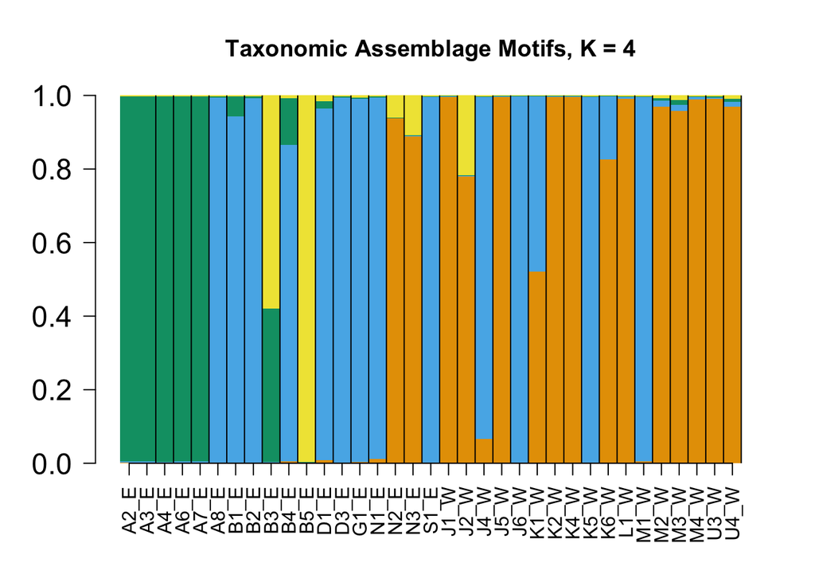

```r
K <- 4
barplot(t(new.K.4$omega[order(elevation_metadata),]),col=cbbPalette[2:(K+1)],axisnames=F,space=0,border=NA,
        main="",las=1,ylim=c(0,1),cex.axis=1.5,cex.main=1.4)
title(main=paste("Taxonomic Assemblage Motifs, K =",K))
combo_patch_dir = paste0(forest_patch_label,"_",east_west_dir);
combo_patch_dir_ordered = combo_patch_dir[order(east_west_dir)];
match_labs=match(unique(combo_patch_dir_ordered),combo_patch_dir_ordered);
match_labs_suffix=c(match_labs[2:length(unique(combo_patch_dir_ordered))],35);
match_labs_prefix=match_labs[1:(length(unique(combo_patch_dir_ordered)))];
labs=match_labs_prefix + 0.5*(match_labs_suffix - match_labs_prefix);
labs=c(0.5,1.5,2.5,3.5,4.5,5.5,6.5,7.5,8.5,9.5,10.5,11.5,12.5,13.5,14.5,15.5,16.5,17.5,18.5,19.5,20.5,21.5,22.5,23.5,24.5,25.5,26.5,27.5,28.5,29.5,30.5,31.5,32.5,33.5,34.5)
axis(1,at=labs,unique(combo_patch_dir_ordered),las=2);
abline(v=match_labs[2:length(match_labs)]);
```

The Structure plot for K=3 is the same and for K=4 it is clearly different. There is no obvious way that new_counts or No zero counts should effect the results of the GoM model except that for No zero counts columns were dropped. Either the wrong columns are being dropped not as intended or the model is sensative to comlumns being included. However, becuase the K=3 result is so similar, the wrong columns problem is not likely the same. I am not sure of the answer, but we should investigate before moving forward.

We look at the theta matrix for the previous fit for the features with all zero abundances across all the forest spots. Ideally the theta values should be pretty small for all these features as they do not contribute much to the clustering.

```r
K.3$theta[which(colSums(new_counts) == 0),]
```

```
##                              topic
## phrase                                   1            2            3
##   Columba_hodgsonii           4.800712e-07 7.221553e-07 8.623809e-07
##   Columba_leuconota           4.800712e-07 7.221553e-07 8.623809e-07
##   Treron_phoenicopterus       4.800712e-07 7.221553e-07 8.623809e-07
##   Hierococcyx_nisicolor       4.800712e-07 7.221553e-07 8.623809e-07
##   Cuculus_poliocephalus       4.800712e-07 7.221553e-07 8.623809e-07
##   Chrysococcyx_maculatus      4.800712e-07 7.221553e-07 8.623809e-07
##   Dinopium_shorii             4.800712e-07 7.221553e-07 8.623809e-07
##   Dendrocopos_cathpharius     4.800712e-07 7.221553e-07 8.623809e-07
##   Strix_nivicola              4.800712e-07 7.221553e-07 8.623809e-07
##   Loriculus_vernalis          4.800712e-07 7.221553e-07 8.623809e-07
##   Spelaeornis_formosus        4.800712e-07 7.221553e-07 8.623809e-07
##   Sturnia_malabarica          4.800712e-07 7.221553e-07 8.623809e-07
##   Tarsiger_hyperythrus        4.800712e-07 7.221553e-07 8.623809e-07
##   Ficedula_subrubra           4.800712e-07 7.221553e-07 8.623809e-07
##   Bradypterus_thoracicus      4.800712e-07 7.221553e-07 8.623809e-07
##   Aegithalos_iouschistos      4.800712e-07 7.221553e-07 8.623809e-07
##   Cettia_brunnescens          4.800712e-07 7.221553e-07 8.623809e-07
##   Ianthocincla_rufogularis    4.800712e-07 7.221553e-07 8.623809e-07
##   Dryonastes_caerulatus       4.800712e-07 7.221553e-07 8.623809e-07
##   Leiothrix_lutea             4.800712e-07 7.221553e-07 8.623809e-07
##   Trochalopteron_imbricatum   4.800712e-07 7.221553e-07 8.623809e-07
##   Trochalopteron_squamatum    4.800712e-07 7.221553e-07 8.623809e-07
##   Xiphirhynchus_superciliaris 4.800712e-07 7.221553e-07 8.623809e-07
##   Lioparus_chrysotis          4.800712e-07 7.221553e-07 8.623809e-07
##   Cephalopyrus_flammiceps     4.800712e-07 7.221553e-07 8.623809e-07
##   Emberiza_cia                4.800712e-07 7.221553e-07 8.623809e-07
##   Callacanthis_burtoni        4.800712e-07 7.221553e-07 8.623809e-07
##   Haematospiza_sipahi         4.800712e-07 7.221553e-07 8.623809e-07
##   Carpodacus_edwardsii        4.800712e-07 7.221553e-07 8.623809e-07
##   Prunella_collaris           4.800712e-07 7.221553e-07 8.623809e-07
##   Aethopyga_gouldiae          4.800712e-07 7.221553e-07 8.623809e-07
##   Pteruthius_rufiventer       4.800712e-07 7.221553e-07 8.623809e-07
##   Coracina_melanoptera        4.800712e-07 7.221553e-07 8.623809e-07
##   Coracina_melaschistos       4.800712e-07 7.221553e-07 8.623809e-07
##   Dicrurus_caerulescens       4.800712e-07 7.221553e-07 8.623809e-07
##   Dicrurus_annectans          4.800712e-07 7.221553e-07 8.623809e-07
##   Urocissa_erythrorhyncha     4.800712e-07 7.221553e-07 8.623809e-07
##   Caprimulgus_macrurus        4.800712e-07 7.221553e-07 8.623809e-07
##   Picus_xanthopygaeus         4.800712e-07 7.221553e-07 8.623809e-07
##   Cettia_pallidipes           4.800712e-07 7.221553e-07 8.623809e-07
##   Nyctyornis_athertoni        4.800712e-07 7.221553e-07 8.623809e-07
##   Pericrocotus_roseus         4.800712e-07 7.221553e-07 8.623809e-07
##   Psittacula_cyanocephala     4.800712e-07 7.221553e-07 8.623809e-07
##   Abroscopus_albogularis      4.800712e-07 7.221553e-07 8.623809e-07
```

```r
K.4$theta[which(colSums(new_counts) == 0),]
```

```
##                              topic
## phrase                                   1            2            3
##   Columba_hodgsonii           5.632807e-07 6.047919e-07 5.634365e-07
##   Columba_leuconota           5.632807e-07 6.047919e-07 5.634365e-07
##   Treron_phoenicopterus       5.632807e-07 6.047919e-07 5.634365e-07
##   Hierococcyx_nisicolor       5.632807e-07 6.047919e-07 5.634365e-07
##   Cuculus_poliocephalus       5.632807e-07 6.047919e-07 5.634365e-07
##   Chrysococcyx_maculatus      5.632807e-07 6.047919e-07 5.634365e-07
##   Dinopium_shorii             5.632807e-07 6.047919e-07 5.634365e-07
##   Dendrocopos_cathpharius     5.632807e-07 6.047919e-07 5.634365e-07
##   Strix_nivicola              5.632807e-07 6.047919e-07 5.634365e-07
##   Loriculus_vernalis          5.632807e-07 6.047919e-07 5.634365e-07
##   Spelaeornis_formosus        5.632807e-07 6.047919e-07 5.634365e-07
##   Sturnia_malabarica          5.632807e-07 6.047919e-07 5.634365e-07
##   Tarsiger_hyperythrus        5.632807e-07 6.047919e-07 5.634365e-07
##   Ficedula_subrubra           5.632807e-07 6.047919e-07 5.634365e-07
##   Bradypterus_thoracicus      5.632807e-07 6.047919e-07 5.634365e-07
##   Aegithalos_iouschistos      5.632807e-07 6.047919e-07 5.634365e-07
##   Cettia_brunnescens          5.632807e-07 6.047919e-07 5.634365e-07
##   Ianthocincla_rufogularis    5.632807e-07 6.047919e-07 5.634365e-07
##   Dryonastes_caerulatus       5.632807e-07 6.047919e-07 5.634365e-07
##   Leiothrix_lutea             5.632807e-07 6.047919e-07 5.634365e-07
##   Trochalopteron_imbricatum   5.632807e-07 6.047919e-07 5.634365e-07
##   Trochalopteron_squamatum    5.632807e-07 6.047919e-07 5.634365e-07
##   Xiphirhynchus_superciliaris 5.632807e-07 6.047919e-07 5.634365e-07
##   Lioparus_chrysotis          5.632807e-07 6.047919e-07 5.634365e-07
##   Cephalopyrus_flammiceps     5.632807e-07 6.047919e-07 5.634365e-07
##   Emberiza_cia                5.632807e-07 6.047919e-07 5.634365e-07
##   Callacanthis_burtoni        5.632807e-07 6.047919e-07 5.634365e-07
##   Haematospiza_sipahi         5.632807e-07 6.047919e-07 5.634365e-07
##   Carpodacus_edwardsii        5.632807e-07 6.047919e-07 5.634365e-07
##   Prunella_collaris           5.632807e-07 6.047919e-07 5.634365e-07
##   Aethopyga_gouldiae          5.632807e-07 6.047919e-07 5.634365e-07
##   Pteruthius_rufiventer       5.632807e-07 6.047919e-07 5.634365e-07
##   Coracina_melanoptera        5.632807e-07 6.047919e-07 5.634365e-07
##   Coracina_melaschistos       5.632807e-07 6.047919e-07 5.634365e-07
##   Dicrurus_caerulescens       5.632807e-07 6.047919e-07 5.634365e-07
##   Dicrurus_annectans          5.632807e-07 6.047919e-07 5.634365e-07
##   Urocissa_erythrorhyncha     5.632807e-07 6.047919e-07 5.634365e-07
##   Caprimulgus_macrurus        5.632807e-07 6.047919e-07 5.634365e-07
```

[output cut: 37 more lines]

```
##   Prunella_collaris           1.034984e-06
##   Aethopyga_gouldiae          1.034984e-06
##   Pteruthius_rufiventer       1.034984e-06
##   Coracina_melanoptera        1.034984e-06
##   Coracina_melaschistos       1.034984e-06
##   Dicrurus_caerulescens       1.034984e-06
##   Dicrurus_annectans          1.034984e-06
##   Urocissa_erythrorhyncha     1.034984e-06
##   Caprimulgus_macrurus        1.034984e-06
##   Picus_xanthopygaeus         1.034984e-06
##   Cettia_pallidipes           1.034984e-06
##   Nyctyornis_athertoni        1.034984e-06
##   Pericrocotus_roseus         1.034984e-06
##   Psittacula_cyanocephala     1.034984e-06
##   Abroscopus_albogularis      1.034984e-06
```

Note that for $K=4$, the fourth cluster indeed has much higher theta values than rest for $K=4$ and for $K=3$, they are pretty similar. I think that is the reason why we see the clustering pattern to remain the same from K.3 to new.K.3 but not from K.4 to new.K.4. I think it is because of some discrepancy in the prior setting most likely. You can see all these features have same theta as should be the case as they all contribute equally (all 0’s), but the difference in theta across the clusters is because of prior settings and that seems to be driving the differences majorly.